# 7 Modelo de Regresión Logística

## 7.1 Introducción

La regresión logística es un método estadístico utilizado para predecir una variable categórica binaria en función de varias variables explicativas. Este análisis permite clasificar el rendimiento académico de los estudiantes en dos categorías: Buen Rendimiento y Mal Rendimiento, en función de diversos factores internos, familiares y escolares.

## 7.2 Preparación de Variables

Para este análisis, se reutiliza la base de datos preparada previamente para la regresión lineal múltiple, `StudentPerformanceFactors_Processed.csv`. Esta base incluye las transformaciones necesarias, como el **One-Hot Encoding** aplicado a las variables categóricas **Involucramiento Parental** y **Calidad del Profesor**.

Además, las variables numéricas seleccionadas, **Horas de Estudio**, **Asistencia** y **Sesiones de Tutoria** se normalizan nuevamente dentro de este capítulo para asegurar que estén en la misma escala, lo que garantiza consistencia en el análisis.

### 7.2.1 Transformación de la Variable Dependiente

La variable dependiente **Buen Rendimiento** refleja el rendimiento académico de los estudiantes y se deriva de la **Puntuación de Examen**, que varía entre 55 y 101 puntos. Para clasificar a los estudiantes, se establece un **punto de corte en 70**:

- Los estudiantes con puntuaciones iguales o superiores a 70 se clasifican como de **Buen Rendimiento** (1).
- Los estudiantes con puntuaciones inferiores a 70 se clasifican como de **Mal Rendimiento** (0).

Este umbral es adecuado para separar a los estudiantes en dos categorías según su desempeño, dado que todos aprobaron el examen. Esta transformación convierte una variable continua en una categórica binaria, lo que permite su análisis mediante regresión logística.

Distribución de la Variable 'Buen Rendimiento'

| Categoría | Frecuencia | Porcentaje (%) |
| --- | --- | --- |
| Mal Rendimiento | 4797 | 75.21 |
| Buen Rendimiento | 1581 | 24.79 |

[interactive chart not shown]

La mayoría de los estudiantes se encuentran en la categoría de Mal Rendimiento (75%), mientras que el 25% restante pertenece a la categoría de Buen Rendimiento. Este desequilibrio en las clases es importante considerar durante el analisis del modelo.

## 7.3 Ajuste del Modelo Logístico

Este modelo incorpora factores internos, externos y escolares considerados relevantes para predecir el rendimiento académico.

```
Call:
glm(formula = Buen_Rendimiento ~ Horas_Estudio + Asistencia +
    Sesiones_Tutoria + Involucramiento_Parental_Alto + Involucramiento_Parental_Medio +
    Calidad_Profesor_Alta + Calidad_Profesor_Media, family = binomial,
    data = student_data)

Coefficients:
                               Estimate Std. Error z value Pr(>|z|)
(Intercept)                    -4.41660    0.19898 -22.196  < 2e-16 ***
Horas_Estudio                   2.00354    0.06660  30.082  < 2e-16 ***
Asistencia                      2.53179    0.07533  33.611  < 2e-16 ***
Sesiones_Tutoria                0.64764    0.04560  14.203  < 2e-16 ***
Involucramiento_Parental_Alto   1.97775    0.13765  14.368  < 2e-16 ***
Involucramiento_Parental_Medio  0.92080    0.12279   7.499 6.43e-14 ***
Calidad_Profesor_Alta           1.15831    0.16522   7.011 2.37e-12 ***
Calidad_Profesor_Media          0.60882    0.15512   3.925 8.68e-05 ***
---
Signif. codes:  0 '***' 0.001 '**' 0.01 '*' 0.05 '.' 0.1 ' ' 1

(Dispersion parameter for binomial family taken to be 1)

    Null deviance: 7143.3  on 6377  degrees of freedom
Residual deviance: 3387.7  on 6370  degrees of freedom
AIC: 3403.7

Number of Fisher Scoring iterations: 7
```

## 7.4 Interpretación del Modelo

### 7.4.1 Odds Ratio

Los odds ratios permiten interpretar cómo varía la probabilidad de obtener un buen rendimiento académico cuando una variable independiente aumenta en una unidad, manteniendo las demás constantes. Se calculan transformando los coeficientes del modelo logístico (β) mediante la función exponencial, facilitando su comprensión.

Interpretación General:  
- **Odds Ratio > 1**: Aumenta la probabilidad del evento (buen rendimiento). Por ejemplo, un odds ratio de 1.5 significa un aumento del 50% en las probabilidades.  
- **Odds Ratio = 1**: No hay efecto; la variable no altera las probabilidades.  
- **Odds Ratio < 1**: Disminuye la probabilidad del evento. Por ejemplo, un odds ratio de 0.8 representa una reducción del 20% en las probabilidades.

**Intervalos de Confianza**:  
Los intervalos de confianza indican la precisión de los odds ratios. Si el intervalo excluye el valor 1, el efecto es estadísticamente significativo.

```
                                                     Variable  Odds.Ratio
(Intercept)                                       (Intercept)  0.01207526
Horas_Estudio                                   Horas_Estudio  7.41527878
Asistencia                                         Asistencia 12.57599928
Sesiones_Tutoria                             Sesiones_Tutoria  1.91103379
Involucramiento_Parental_Alto   Involucramiento_Parental_Alto  7.22648505
Involucramiento_Parental_Medio Involucramiento_Parental_Medio  2.51128845
Calidad_Profesor_Alta                   Calidad_Profesor_Alta  3.18456223
Calidad_Profesor_Media                 Calidad_Profesor_Media  1.83826829
                                CI.Inferior CI.Superior
(Intercept)                     0.008123321  0.01772446
Horas_Estudio                   6.522876723  8.46940329
Asistencia                     10.881028871 14.61977108
Sesiones_Tutoria                1.748796535  2.09119571
Involucramiento_Parental_Alto   5.532509338  9.49129411
Involucramiento_Parental_Medio  1.977761428  3.20093510
Calidad_Profesor_Alta           2.310272839  4.41629127
Calidad_Profesor_Media          1.360011316  2.49887482
```

- **Horas de Estudio**: Aumentar una hora incrementa los odds de buen rendimiento en 7.42 veces.
- **Asistencia**: Incrementa los odds en 12.58 veces, siendo el factor más influyente del modelo.
- **Sesiones de Tutoría**: Participar en tutorías aumenta los odds en 1.91 veces, mostrando un efecto positivo pero menor.
- **Involucramiento Parental**:
  - **Alto**: Incrementa los odds en 7.23 veces respecto al bajo.
  - **Medio**: Incrementa los odds en 2.51 veces respecto al bajo. Esto refleja que el apoyo parental es más relevante cuando es alto.
- **Calidad del Profesor**:
  - **Alta**: Incrementa los odds en 3.18 veces respecto a la baja.
  - **Media**: Incrementa los odds en 1.84 veces respecto a la baja. Esto sugiere que una percepción positiva de la calidad docente favorece el rendimiento.

En este modelo todos los intervalos de confianza excluyen el valor 1, lo que respalda la relevancia estadística de las variables. Entre los factores, la asistencia y las horas de estudio destacan como los más importantes.

### 7.4.2 Bondad de Ajuste

Evaluamos el ajuste del modelo utilizando dos métricas clave:

#### 7.4.2.1 Prueba de Hosmer-Lemeshow

Esta prueba evalúa si las probabilidades predichas por el modelo se ajustan bien a las observaciones reales.

```
    Hosmer and Lemeshow goodness of fit (GOF) test

data:  student_data$Buen_Rendimiento, fitted(modelo_log_completo)
X-squared = 199.43, df = 8, p-value < 2.2e-16
```

Un valor p inferior a 0.05 indicaría que el modelo no se ajusta perfectamente a los datos observados. Esto podría señalar la necesidad de refinar el modelo o considerar interacciones adicionales.

#### 7.4.2.2 Criterio de Información de Akaike (AIC)

El AIC del modelo es 3403.7, lo que indica un equilibrio razonable entre el ajuste y la complejidad del modelo.

## 7.5 Evaluación del Modelo

### 7.5.1 Curva ROC

La curva ROC y el área bajo la curva (AUC) son métricas fundamentales para evaluar la capacidad del modelo de clasificar correctamente los casos positivos y negativos.

- Una AUC cercana a 1 indica un excelente desempeño del modelo.
- Una AUC cercana a 0.5 indica un modelo sin capacidad de discriminación.

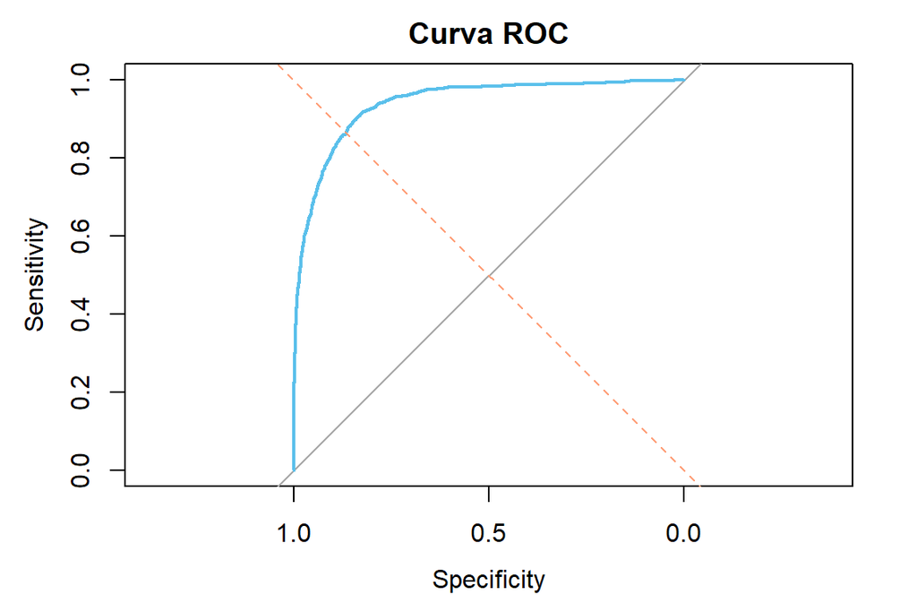

```
Area under the curve: 0.9393
```

La AUC obtenida es de 0.9393093, lo que indica que el modelo tiene una capacidad aceptable para discriminar entre estudiantes con buen y mal rendimiento académico.

### 7.5.2 Matriz de Confusión

La matriz de confusión es una herramienta fundamental para evaluar el desempeño de modelos de clasificación. Permite comparar las predicciones del modelo con las clases reales y obtener información clave como:

- **Verdaderos Positivos (VP)**: Casos correctamente clasificados como Buen Rendimiento.
- **Verdaderos Negativos (VN)**: Casos correctamente clasificados como Mal Rendimiento.
- **Falsos Positivos (FP)**: Casos incorrectamente clasificados como Buen Rendimiento.
- **Falsos Negativos (FN)**: Casos incorrectamente clasificados como Mal Rendimiento.

Estos valores son la base para calcular métricas como precisión, sensibilidad y especificidad.

Utilizamos un umbral de 0.5 para clasificar las predicciones.

Matriz de Confusión

[output not shown]

### 7.5.3 Métricas de Clasificación

Para evaluar la calidad del modelo, calculamos las siguientes métricas:

- **Precisión**: Proporción de predicciones correctas entre todos los casos predichos como positivos.
- **Sensibilidad (Recall)**: Capacidad del modelo para identificar correctamente los casos positivos.
- **Especificidad**: Capacidad del modelo para identificar correctamente los casos negativos.

```
        Metrica     Valor
1     Precisión 0.7958188
2  Sensibilidad 0.7223276
3 Especificidad 0.9389202
```

- **Precisión**: 79.58% de los casos clasificados como Buen Rendimiento fueron correctos.
- **Sensibilidad**: El modelo identificó correctamente 72.23% de los estudiantes con Buen Rendimiento.
- **Especificidad**: El modelo identificó correctamente 93.89% de los estudiantes con Mal Rendimiento.

Estas métricas reflejan un desempeño adecuado del modelo, aunque podrían mejorarse mediante ajustes adicionales.

## 7.6 Conclusión

La regresión logística permitió clasificar a los estudiantes según su rendimiento académico, destacando **Asistencia** y **Horas de Estudio** como los factores más relevantes, con un impacto significativo en el buen rendimiento, similar a la regresión lineal múltiple. En contraste, **Sesiones de Tutoría** mostró un efecto limitado, sugiriendo que su relevancia en el modelo es menor.

Sin embargo, los resultados de la **Prueba de Hosmer-Lemeshow** ((p < 0.05)) indican que el modelo no se ajusta perfectamente a los datos observados, aunque el AUC y las métricas de clasificación, como sensibilidad y especificidad, muestran un desempeño razonable. Esto sugiere la necesidad de realizar ajustes para mejorar la capacidad predictiva del modelo.

Como primera acción, podría eliminarse la variable **Sesiones de Tutoría** para simplificar el modelo y evaluar su impacto en el ajuste. Además, incorporar otras variables podría mejorar su desempeño.

Este modelo resalta la importancia de factores clave como la asistencia y las horas de estudio, lo que brinda un punto de partida para diseñar intervenciones educativas prácticas. Sin embargo, debe refinarse para garantizar una mejor correlación con la realidad y una mayor utilidad en la toma de decisiones.